# LION 2026 in 4 Visuals

Energy and fitness trade-offs in the Brave New Algorithm

JJ Merelo & Cecilia Merelo-Molina & Pablo García Sánchez & Mario García Valdez & Juan Luis Jiménez-Laredo

June 2026

```r
library(ggplot2)
library(dplyr)

if (!requireNamespace("energyR", quietly = TRUE)) {
  if (file.exists("energyR/DESCRIPTION")) {
    pkg_path <- normalizePath("energyR", mustWork = TRUE)
    utils::install.packages(pkg_path, repos = NULL, type = "source")
  } else {
    stop("Package 'energyR' is required. Install it or render from the repository root.")
  }
}

library(energyR)
```

## Introduction

The LION paper analyzes the Brave New Algorithm (BNA), a caste-stratified population-based stochastic optimization algorithm, measuring fitness and energy jointly (Merelo-Guervós et al. 2026; Merelo, Merelo, and Garcı́a-Valdez 2022). The optimization task in this study is the BBOB Sphere function (Hansen et al. 2010).

## Data preparation with `energyR`

```r
# LION (Julia 1.11.8)
lion_baseline <- load_bna_csv("data/lion-1.11.8-baseline.csv")
lion_summary <- summarize_baseline(lion_baseline)

lion_workload <- load_bna_csv("data/lion-1.11.8-bna-fix-rand.csv", drop_baseline_cols = FALSE)
lion_workload <- prepare_workload(lion_summary, lion_workload, label_col = "dim_pop")
lion_workload$julia <- "1.11.8"

# EvoApps baseline/workload used in the paper as the previous platform (Julia 1.11.7)
prev_baseline <- load_bna_csv("data/evoapps-1.11.7-baseline-bna-baseline-16-Oct-11-08-20.csv")
prev_summary <- summarize_baseline(prev_baseline)

prev_workload <- load_bna_csv("data/evoapps-1.11.7-fix-rand-bna-fix-rand-25-Oct-11-06-07.csv", drop_baseline_cols = FALSE)
prev_workload <- prepare_workload(prev_summary, prev_workload, label_col = "dim_pop")
prev_workload$julia <- "1.11.7"
```

## 1) Baseline is variable, so subtraction matters

Before looking at algorithmic effects, we need to separate them from runtime and platform overhead. The baseline plot shows non-negligible dispersion, and that dispersion depends on dimension and population size.

This is one of the main methodological conclusions of the paper: comparing raw Joules between configurations is misleading, so baseline-corrected deltas are the defensible unit for comparisons (Merelo-Guervós et al. 2026; Cotta and Martı́nez-Cruz 2024).

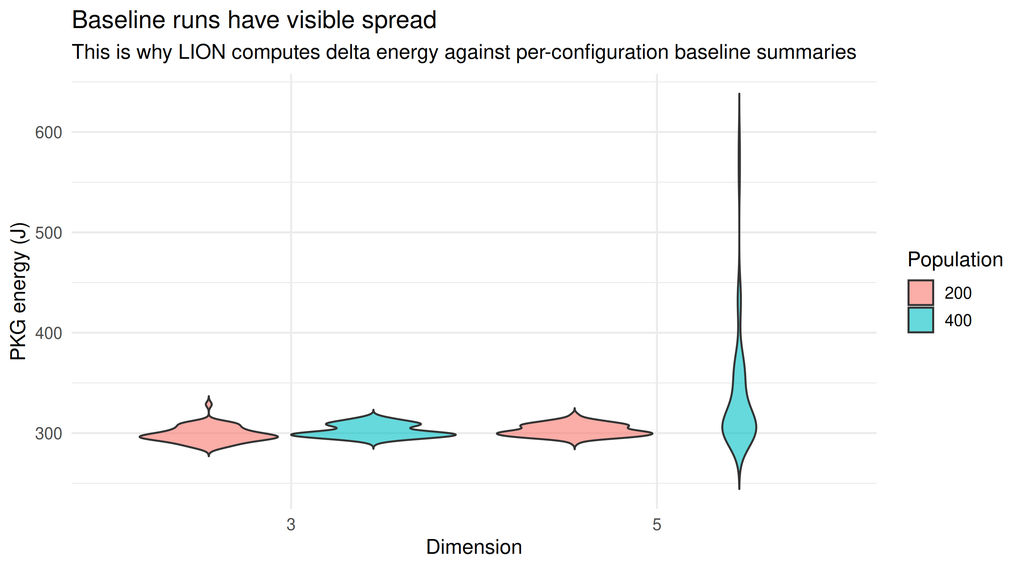

Baseline PKG distribution by dimension and population size (LION, Julia 1.11.8).

```r
plot_data <- lion_baseline %>%
  mutate(
    dimension = as.factor(dimension),
    population_size = as.factor(population_size)
  )

ggplot(plot_data, aes(x = dimension, y = PKG, fill = population_size)) +
  geom_violin(alpha = 0.6, trim = FALSE) +
  theme_minimal(base_size = 13) +
  labs(
    title = "Baseline runs have visible spread",
    subtitle = "This is why LION computes delta energy against per-configuration baseline summaries",
    x = "Dimension",
    y = "PKG energy (J)",
    fill = "Population"
  )
```

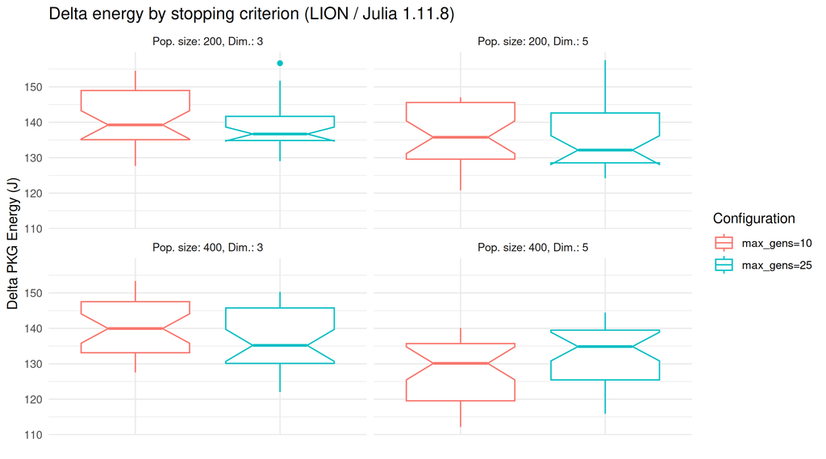

Delta energy in LION workload runs, grouped by max_gens and faceted by parameter combination.

```r
lion_for_plot <- lion_workload %>%
  mutate(
    work = paste0("max_gens=", max_gens),
    dim_pop = factor(dim_pop)
  )

plot_delta_energy(
  lion_for_plot,
  geom = "boxplot",
  facet_col = "dim_pop",
  title = "Delta energy by stopping criterion (LION / Julia 1.11.8)"
)
```

## 3) Energy vs fitness is a trade-off, not a single objective

This plot makes explicit what the paper discusses in detail: there is no universal setting that simultaneously optimizes energy and fitness in every case. Points do not collapse into a single dominant frontier.

Operationally, that means configuration should be policy-driven. If your context prioritizes lower energy, choose from the lower-energy clusters; if it prioritizes better fitness improvements, accept the additional energy budget and select accordingly (Merelo-Guervós et al. 2026).

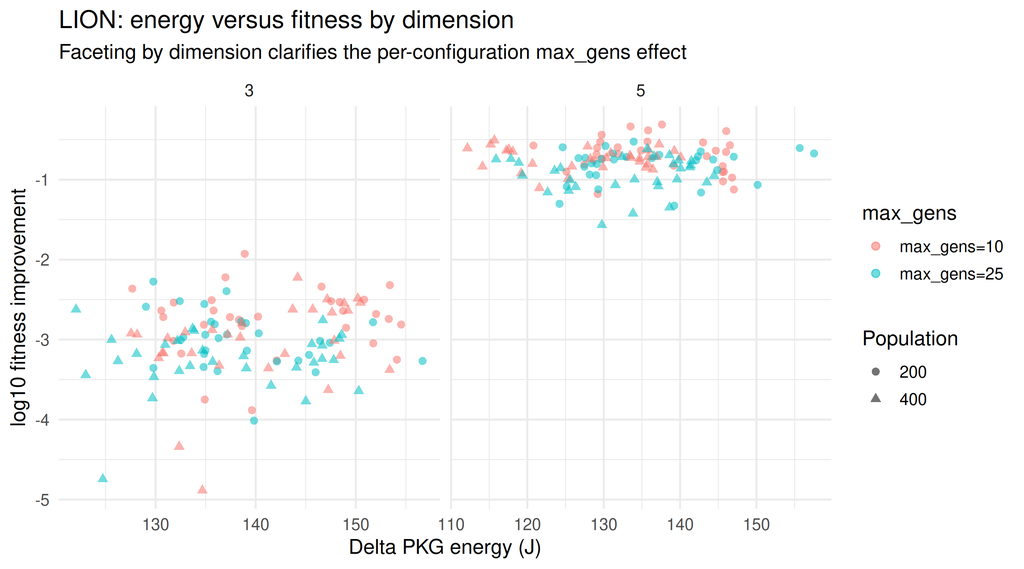

Energy-versus-fitness view for LION runs, faceted by problem dimension and grouped by max_gens/population.

```r
lion_tradeoff <- lion_for_plot %>%
  filter(is.finite(log_diff), diff_fitness > 0) %>%
  mutate(
    work = factor(paste0("max_gens=", max_gens)),
    dimension = factor(dimension),
    population_size = factor(population_size)
  )

ggplot(lion_tradeoff, aes(x = delta_PKG, y = log_diff, color = work, shape = population_size)) +
  geom_point(alpha = 0.55, size = 2) +
  facet_wrap(~dimension, nrow = 1, scales = "free_x") +
  theme_minimal(base_size = 13) +
  labs(
    title = "LION: energy versus fitness by dimension",
    subtitle = "Faceting by dimension clarifies the per-configuration max_gens effect",
    x = "Delta PKG energy (J)",
    y = "log10 fitness improvement",
    color = "max_gens",
    shape = "Population"
  )
```

## 4) Platform drift: Julia version alone changes the energy baseline-corrected profile

One of the strongest discussion points in the paper is reproducibility under software platform evolution. The comparison across Julia versions shows that runtime/platform updates can materially shift measured energy, even when the algorithmic procedure is unchanged (Merelo-Guervós et al. 2026).

So, any claim of “configuration A is greener than B” should be version-scoped and re-validated after upgrades. In practice, rerunning baseline + workload after runtime changes is part of the protocol, not a nice-to-have (Cotta and Martı́nez-Cruz 2024; Merelo-Guervós et al. 2026).

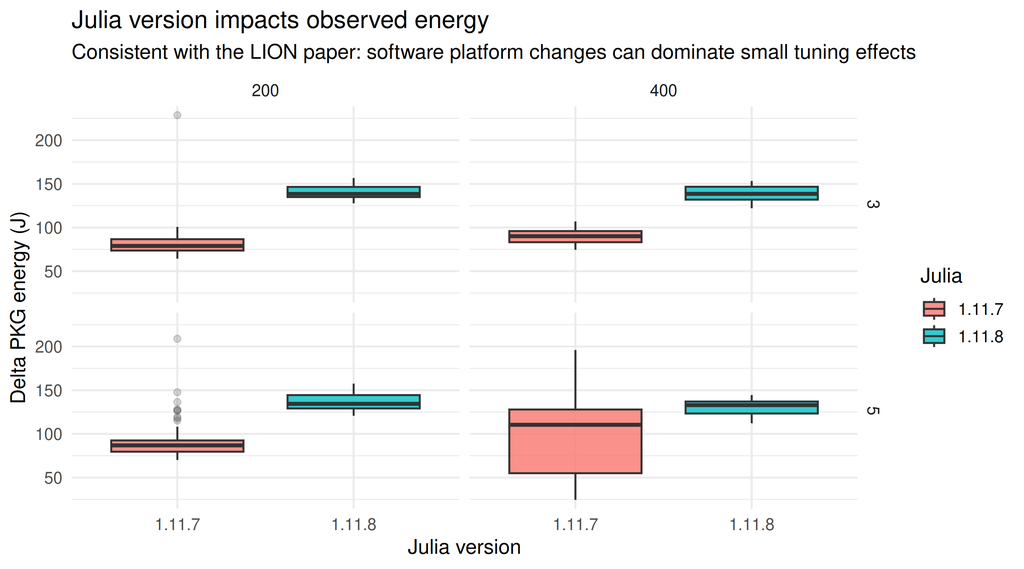

Comparing baseline-corrected workload energy for similar BNA settings across Julia versions used in the paper.

```r
version_compare <- bind_rows(
  prev_workload %>% mutate(source = "EvoApps setup"),
  lion_workload %>% mutate(source = "LION setup")
) %>%
  mutate(
    population_size = as.factor(population_size),
    dimension = as.factor(dimension)
  )

ggplot(version_compare, aes(x = julia, y = delta_PKG, fill = julia)) +
  geom_boxplot(alpha = 0.8, outlier.alpha = 0.2) +
  facet_grid(dimension ~ population_size) +
  theme_minimal(base_size = 13) +
  labs(
    title = "Julia version impacts observed energy",
    subtitle = "Consistent with the LION paper: software platform changes can dominate small tuning effects",
    x = "Julia version",
    y = "Delta PKG energy (J)",
    fill = "Julia"
  )
```

## Compact configuration summary

```r
wilcoxon_flags <- lion_workload %>%
  filter(is.finite(delta_PKG)) %>%
  group_by(dimension, population_size) %>%
  group_modify(~{
    gens <- sort(unique(.x$max_gens))
    if (length(gens) < 2) {
      return(data.frame(max_gens = numeric(0)))
    }
    pair_tests <- utils::combn(gens, 2, simplify = FALSE)
    sig_rows <- lapply(pair_tests, function(pair) {
      x <- .x$delta_PKG[.x$max_gens == pair[1]]
      y <- .x$delta_PKG[.x$max_gens == pair[2]]
      p_value <- stats::wilcox.test(x, y, exact = FALSE)$p.value
      if (is.finite(p_value) && p_value < 0.05) {
        data.frame(max_gens = pair)
      } else {
        NULL
      }
    })
    sig_rows <- sig_rows[!vapply(sig_rows, is.null, logical(1))]
    if (length(sig_rows) == 0) {
      return(data.frame(max_gens = numeric(0)))
    }
    dplyr::bind_rows(sig_rows) %>% distinct(max_gens)
  }) %>%
  ungroup() %>%
  distinct(dimension, population_size, max_gens) %>%
  mutate(sig_mark = "*")

lion_summary_table <- create_summary(lion_workload) %>%
  left_join(
    wilcoxon_flags,
    by = c("dimension", "population_size", "max_gens")
  ) %>%
  arrange(trimmed_mean_delta_PKG) %>%
  mutate(
    setting = paste0(
      "D=", dimension, ", P=", population_size, ", max_gens=", max_gens,
      ifelse(is.na(sig_mark), "", sig_mark)
    ),
    trimmed_mean_delta_PKG = round(trimmed_mean_delta_PKG, 2),
    trimmed_mean_energy_per_evaluation = signif(trimmed_mean_energy_per_evaluation, 3)
  ) %>%
  select(setting, trimmed_mean_delta_PKG, trimmed_mean_energy_per_evaluation)

knitr::kable(
  lion_summary_table,
  col.names = c("Setting", "Trimmed mean delta PKG (J)", "Trimmed mean J/evaluation"),
  caption = "Lower values are better for energy-only efficiency. * marks configurations with Wilcoxon-significant (p < 0.05) delta-PKG differences versus at least one other max_gens in the same (dimension, population) group."
)
```

Lower values are better for energy-only efficiency. * marks configurations with Wilcoxon-significant (p < 0.05) delta-PKG differences versus at least one other max_gens in the same (dimension, population) group.

| Setting | Trimmed mean delta PKG (J) | Trimmed mean J/evaluation |
| --- | --- | --- |
| D=5, P=400, max_gens=10* | 128.97 | 0.001650 |
| D=5, P=400, max_gens=25* | 133.64 | 0.000844 |
| D=5, P=200, max_gens=25 | 134.23 | 0.001720 |
| D=5, P=200, max_gens=10 | 137.03 | 0.003620 |
| D=3, P=400, max_gens=25 | 137.38 | 0.000800 |
| D=3, P=200, max_gens=25 | 137.55 | 0.001620 |
| D=3, P=400, max_gens=10 | 140.42 | 0.001780 |
| D=3, P=200, max_gens=10 | 141.36 | 0.003570 |

The table is useful as an at-a-glance ranking, but it should be read as a screening tool. Final decisions should combine this with fitness outcomes and with the platform/version context highlighted above.

## Expanded analysis: multi-stage model on the final LION dataset

This section applies the later-paper multi-stage modeling workflow directly to the final LION workload file `data/lion-1.11.8-bna-fix-rand.csv` (Merelo-Guervós et al. 2026; Cotta and Martı́nez-Cruz 2024):

1. model runtime (`seconds`) from algorithm covariates (`dimension`, `population_size`, `generations`, `evaluations`);
2. residualize runtime;
3. model energy (`PKG`) on the same covariates plus residualized runtime.

```r
lion_model_data <- read.csv("data/lion-1.11.8-bna-fix-rand.csv") %>%
  mutate(
    dimension = as.numeric(dimension),
    population_size = as.numeric(population_size),
    generations = as.numeric(generations),
    evaluations = as.numeric(evaluations),
    max_gens = factor(max_gens),
    alpha = factor(alpha)
  )

parameter_levels <- data.frame(
  parameter = c("dimension", "population_size", "max_gens", "alpha"),
  levels_in_dataset = c(
    dplyr::n_distinct(lion_model_data$dimension),
    dplyr::n_distinct(lion_model_data$population_size),
    dplyr::n_distinct(lion_model_data$max_gens),
    dplyr::n_distinct(lion_model_data$alpha)
  )
)

knitr::kable(
  parameter_levels,
  col.names = c("Parameter", "Observed levels in data"),
  caption = "Observed support of key algorithm parameters in the final LION dataset."
)
```

Observed support of key algorithm parameters in the final LION dataset.

| Parameter | Observed levels in data |
| --- | --- |
| dimension | 2 |
| population_size | 2 |
| max_gens | 2 |
| alpha | 1 |

In this specific file, `alpha` appears with a single observed value, so it has no within-dataset variance for coefficient estimation; `max_gens` appears with two levels and is reflected through realized `generations` and `evaluations` in the multi-stage modeling path above.

```r
time_model <- lm(
  seconds ~ dimension + population_size + generations + evaluations,
  data = lion_model_data
)
lion_model_data$residual_seconds <- residuals(time_model)

time_coef <- summary(time_model)$coefficients
time_coef_table <- data.frame(
  term = rownames(time_coef),
  estimate = time_coef[, "Estimate"],
  std_error = time_coef[, "Std. Error"],
  statistic = time_coef[, "t value"],
  p_value = time_coef[, "Pr(>|t|)"],
  row.names = NULL
) %>%
  filter(term != "(Intercept)") %>%
  arrange(p_value)

time_sig_table <- time_coef_table %>%
  filter(p_value < 0.05) %>%
  mutate(
    estimate = signif(estimate, 4),
    std_error = signif(std_error, 3),
    statistic = signif(statistic, 3),
    p_value = signif(p_value, 3)
  )

if (nrow(time_sig_table) == 0) {
  time_sig_table <- data.frame(
    term = "No coefficient with p < 0.05",
    estimate = NA, std_error = NA, statistic = NA, p_value = NA
  )
}

knitr::kable(
  time_sig_table,
  col.names = c("Term", "Estimate", "Std. error", "t", "p-value"),
  caption = "Stage 1 (runtime model): statistically significant coefficients."
)
```

Stage 1 (runtime model): statistically significant coefficients.

| Term | Estimate | Std. error | t | p-value |
| --- | --- | --- | --- | --- |
| No coefficient with p < 0.05 | NA | NA | NA | NA |

```r
energy_model <- lm(
  PKG ~ dimension + population_size + generations + evaluations + residual_seconds,
  data = lion_model_data
)

energy_coef <- summary(energy_model)$coefficients
energy_coef_table <- data.frame(
  term = rownames(energy_coef),
  estimate = energy_coef[, "Estimate"],
  std_error = energy_coef[, "Std. Error"],
  statistic = energy_coef[, "t value"],
  p_value = energy_coef[, "Pr(>|t|)"],
  row.names = NULL
) %>%
  filter(term != "(Intercept)") %>%
  arrange(p_value)

energy_sig_table <- energy_coef_table %>%
  filter(p_value < 0.05) %>%
  mutate(
    estimate = signif(estimate, 4),
    std_error = signif(std_error, 3),
    statistic = signif(statistic, 3),
    p_value = signif(p_value, 3)
  )

if (nrow(energy_sig_table) == 0) {
  energy_sig_table <- data.frame(
    term = "No coefficient with p < 0.05",
    estimate = NA, std_error = NA, statistic = NA, p_value = NA
  )
}

knitr::kable(
  energy_sig_table,
  col.names = c("Term", "Estimate", "Std. error", "t", "p-value"),
  caption = "Stage 2 (energy model): statistically significant coefficients influencing PKG."
)
```

Stage 2 (energy model): statistically significant coefficients influencing PKG.

| Term | Estimate | Std. error | t | p-value |
| --- | --- | --- | --- | --- |
| residual_seconds | 49.2 | 19.5 | 2.52 | 0.0124 |

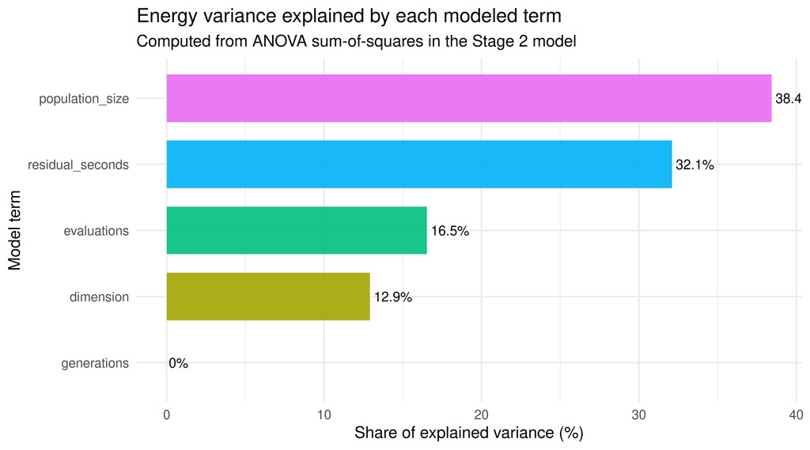

Variance decomposition for the multi-stage energy model (percent of model sum of squares by term).

```r
energy_anova <- anova(energy_model)
energy_variance <- data.frame(
  term = rownames(energy_anova),
  sum_sq = energy_anova$"Sum Sq",
  p_value = energy_anova$"Pr(>F)",
  row.names = NULL
) %>%
  filter(!is.na(sum_sq), term != "Residuals") %>%
  mutate(
    variance_pct = 100 * sum_sq / sum(sum_sq),
    term = factor(term, levels = term[order(variance_pct)])
  )

ggplot(energy_variance, aes(x = term, y = variance_pct, fill = term)) +
  geom_col(width = 0.72, alpha = 0.9) +
  geom_text(
    aes(label = paste0(round(variance_pct, 1), "%")),
    hjust = -0.1,
    size = 3.8
  ) +
  coord_flip() +
  theme_minimal(base_size = 13) +
  theme(legend.position = "none") +
  labs(
    title = "Energy variance explained by each modeled term",
    subtitle = "Computed from ANOVA sum-of-squares in the Stage 2 model",
    x = "Model term",
    y = "Share of explained variance (%)"
  )
```

```r
energy_variance_table <- energy_variance %>%
  mutate(
    variance_pct = round(variance_pct, 2),
    p_value = signif(p_value, 3)
  ) %>%
  arrange(desc(variance_pct)) %>%
  select(term, variance_pct, p_value)

knitr::kable(
  energy_variance_table,
  col.names = c("Term", "Explained variance (%)", "p-value"),
  caption = "ANOVA-based variance share by term for the multi-stage energy model."
)
```

ANOVA-based variance share by term for the multi-stage energy model.

| Term | Explained variance (%) | p-value |
| --- | --- | --- |
| population_size | 38.43 | 0.00628 |
| residual_seconds | 32.10 | 0.01240 |
| evaluations | 16.54 | 0.07170 |
| dimension | 12.92 | 0.11100 |
| generations | 0.01 | 0.97100 |

## Discussion highlights from the paper

- **Measurement methodology matters as much as algorithm design:** baseline correction and careful sampling choices directly influence the conclusions you can trust (Merelo-Guervós et al. 2026; Cotta and Martı́nez-Cruz 2024).
- **Energy is a first-class optimization objective:** if it is not explicitly included in analysis, tuning decisions can look good on fitness while being unnecessarily expensive energetically (Merelo-Guervós et al. 2026).
- **Results are contextual, not absolute:** hardware state, runtime version, and execution environment can dominate small parameter effects (Merelo-Guervós et al. 2026; Cotta and Martı́nez-Cruz 2024).
- **Reproducibility requires protocol, not just code:** to compare studies over time, rerun baseline and workload suites under each relevant software/hardware change (Merelo-Guervós et al. 2026).
- **Actionable takeaway:** report both fitness and energy, and present trade-off-aware recommendations instead of one-number “best setting” claims (Merelo-Guervós et al. 2026; Merelo, Merelo, and Garcı́a-Valdez 2022).

## References

Cotta, Carlos, and Jesús Martı́nez-Cruz. 2024. “Energy Consumption Analysis of Batch Runs of Evolutionary Algorithms.” In *Proceedings of the Genetic and Evolutionary Computation Conference Companion*, 87–88. GECCO ’24 Companion. New York, NY, USA: Association for Computing Machinery. https://doi.org/10.1145/3638530.3664093.

Hansen, Nikolaus, Anne Auger, Raymond Ros, Steffen Finck, and Petr Pošı́k. 2010. “Comparing Results of 31 Algorithms from the Black-Box Optimization Benchmarking BBOB-2009.” In *Proceedings of the 12th Annual Conference Companion on Genetic and Evolutionary Computation*, 1689–96.

Merelo, Cecilia, Juan J Merelo, and Mario Garcı́a-Valdez. 2022. “A Brave New Algorithm to Maintain the Exploration/Exploitation Balance.” In *New Perspectives on Hybrid Intelligent System Design Based on Fuzzy Logic, Neural Networks and Metaheuristics*, 305–16. Springer.

Merelo-Guervós, Juan J., Cecilia Merelo-Molina, Pablo García-Sánchez, and Mario García-Valdez. 2026. “Is There a (Carbon-) Free Lunch? Energy/Performance Tradeoffs in Population-Based Metaheuristics.”